# Основи регресійного моделювання

Прогнозування ринкової вартості житлової нерухомості у мегаполісах США

Софія Кухар

2026-11-23

## 1. Дослідницьке питання та гіпотези

- **Предметна область:** ринок житлової нерухомості у 8 містах США ($N = 50\,000$).
- **Одиниця та ціль:** окремий житловий об’єкт; цільова змінна — `Price_USD` (в USD).
- **Головне питання:** *Як площа та місто визначають ціну житла і наскільки точно лінійна регресія прогнозує нові об’єкти?*
- **Гіпотези (до оцінювання моделей):**
  - **$H_1$ (конфірматорна, Rosen, 1974):** збільшення `Area_sqft` має додатний лінійний зв’язок із `Price_USD`.
  - **$H_2$ (розвідувальна, Sirmans et al., 2005 + EDA):** вартість $1\text{ sq.ft}$ суттєво відрізняється між містами (`Area_sqft * Location`).

## 2. Дані, очищення та протокол валідації

- **Аудит даних:** $50\,000$ об’єктів, без дублікатів; виключено `House_ID` та `Floor` ($74.9\%$ структурних пропусків — заповнена лише для квартир).
- **Захист від витоку:** випадковий поділ **80% Train ($40\,000$) / 20% Test ($10\,000$)** (`seed = 42`) до EDA та навчання.
- **Схема відбору:** **5-кратна крос-валідація (`5-fold CV`)** на навчальній частині.
- **Основна метрика — MAE (USD):** стійка до гетероскедастичності у дорогому сегменті та прямо вимірює типову помилку в доларах.

## 3. Ключова знахідка EDA: ефект взаємодії

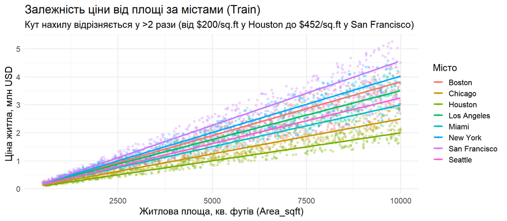

## 4. Діагностика базової моделі (OLS без взаємодії)

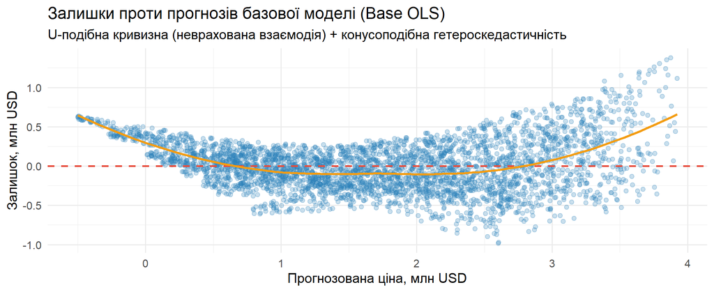

## 5. Порівняння моделей на 5-Fold CV (Train)

| Модель | MAE (середнє, USD) | MAE (SD) | RMSE (середнє, USD) | RMSE (SD) |
| --- | --- | --- | --- | --- |
| 1. Константний орієнтир (Mean) | 866079 | 9681 | 1044924 | 10363 |
| 2. Базова регресія (OLS) | 247826 | 1904 | 314090 | 2958 |
| 3. OLS + взаємодія (Area * Location) | 174803 | 2236 | 233307 | 2838 |

- Додавання взаємодії `Area_sqft * Location` знижує **MAE на $29.6\%$** порівняно з базовою OLS.

## 6. Фінальна оцінка на тестовій вибірці ($n = 10\,000$)

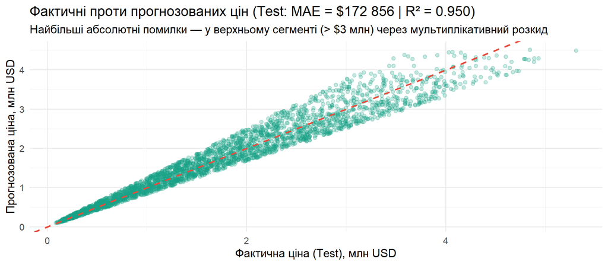

## 7. Висновки та межі узагальнення

- **Обидві гіпотези підтверджено:** площа — головний драйвер ціни ($H_1$), а її гранична вартість відрізняється між містами ($H_2$, $p < 0.001$ з робастними похибками `HC3`).
- **Якість на нових даних:** $\text{Test MAE} = \$172\,856$ (проти $\$855\,510$ для константи), $R^2_{\text{test}} = 0.950$.
- **Межі висновків:** оцінки відображають статистичні асоціації для 8 мегаполісів США; у даних відсутні якісні характеристики ремонту та району.
- **Подальший крок:** застосування **WLS** або **логарифмічної моделі** $\log(\text{Price\_USD})$ для стабілізації дисперсії залишків.